# Craigslist Personals Ads Analysis

Dan Conroy-Beam

2022-12-07

# Q1: What are the demographics of Craigslist?

### Q1.1: Ads come overwhelmingly from men seeking men and men seeking women

```
##      gso   freq  prop
## 2    m4m 254415 44.32
## 6    m4w 209447 36.49
## 18   w4m  30182  5.26
## 4   m4mw  22426  3.91
## 5    m4t   9402  1.64
## 14   t4m   9134  1.59
## 1     NA   7449  1.30
## 22   w4w   6983  1.22
## 13  mw4w   6955  1.21
## 11 mw4mw   4747  0.83
## 10  mw4m   4613  0.80
## 3   m4mm   3156  0.55
## 7   m4ww   1300  0.23
## 9   mm4w   1257  0.22
## 16   t4t    545  0.09
## 20  w4mw    478  0.08
## 19  w4mm    414  0.07
## 8   mm4m    360  0.06
## 15  t4mw    234  0.04
## 17   t4w    202  0.04
## 12  mw4t    146  0.03
## 24  ww4m     72  0.01
## 23  w4ww     58  0.01
## 21   w4t     49  0.01
## 25  ww4w      9  0.00
```

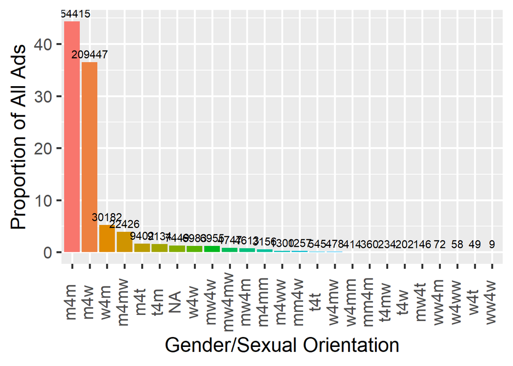

### Q1.2: Heterosexual men grealy outnumber heterosexual women and gay men greatly outnumber lesbians

Ratio of heterosexual men to heterosexual women: 6.94  
Ratio of gay men to lesbians: 36.43

### Q1.4 People are strategically sensitive to market forces

Ad posters could optionally provide information on a number of ancillary characteristics (e.g., height, weight, eye color, etc.).

Given the imbalanced ratios of different gender/sexual orientation groups, some posters found themselves in very in-demand groups (there were many more people seeking that group than posting from that group) whereas others found themselves in relatively low-demand groups (there were many more people posting from that group than seeking that group)

People from more in-demand groups provided less optional information than did people from lower demand groups:

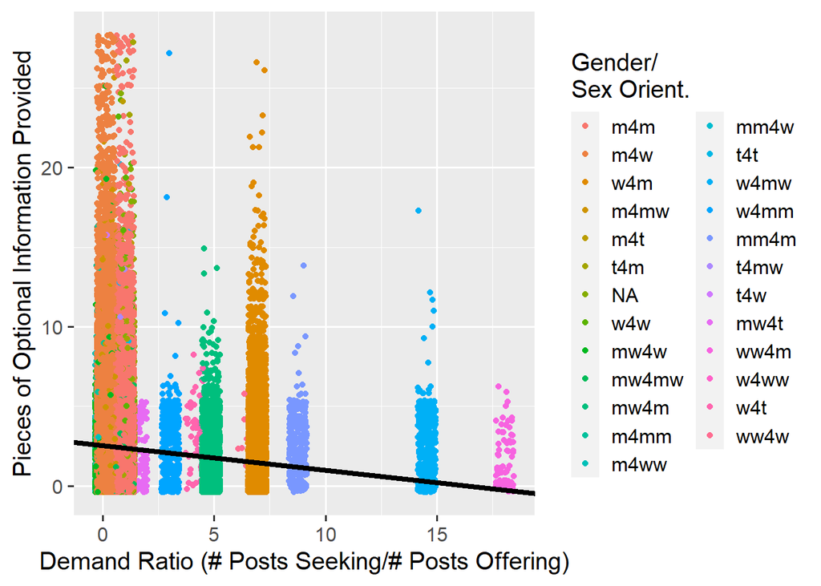

```
## Linear mixed model fit by REML. t-tests use Satterthwaite's method [
## lmerModLmerTest]
## Formula: infoNum ~ dRatio + (1 | gsoPair)
##    Data: data
##
## REML criterion at convergence: 2443185
##
## Scaled residuals:
##     Min      1Q  Median      3Q     Max
## -1.5442 -0.7310 -0.2146  0.7453 12.5819
##
## Random effects:
##  Groups   Name        Variance Std.Dev.
##  gsoPair  (Intercept) 0.1431   0.3782
##  Residual             4.1295   2.0321
## Number of obs: 574033, groups:  gsoPair, 15
##
## Fixed effects:
##               Estimate Std. Error         df t value Pr(>|t|)
## (Intercept)  2.536e+00  9.966e-02  1.349e+01   25.45 8.56e-13 ***
## dRatio      -1.550e-01  1.691e-03  5.740e+05  -91.66  < 2e-16 ***
## ---
## Signif. codes:  0 '***' 0.001 '**' 0.01 '*' 0.05 '.' 0.1 ' ' 1
##
## Correlation of Fixed Effects:
##        (Intr)
## dRatio -0.017
```

### Q1.5: Most people are single, but a sizeable number are in a relationship

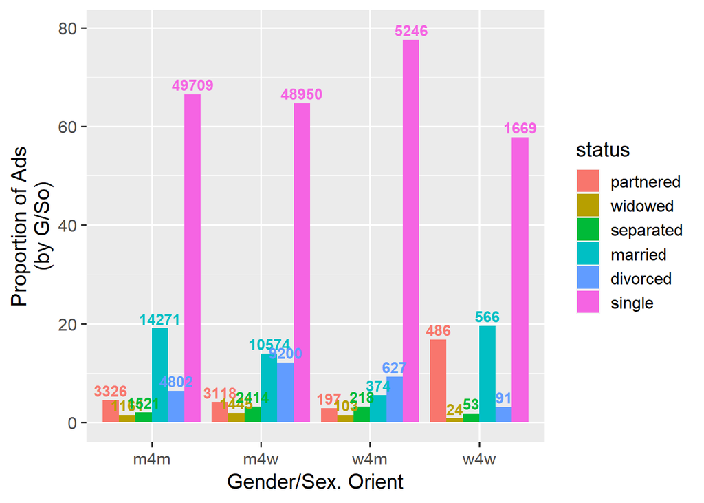

Many of these appear to be bisexual men (2.32% and women (5.84%) looking for same-sex partners. This is less the case for people looking for opposite-sex partners (1.31%) and women (0.29%)

For w4w primarily, many are also couples seeking a third:  
w4w: 7.62%  
m4w: 2.74%  
w4m: 0.42%  
m4m: 1.61%

# Q2: What are the themes of Craigslist?

Theme labels were generated in a multi-step process.

1. 3 RAs independently read the factor loadings but *not* the ads  
   These RAs generated independent labels for the themes  
   These were adjusted to a set of consensus labels based on discussion
2. At this point, the factor solution was adjusted slightly due to loss of the original files  
   The factors remained largely the same, but some factors split DCB re-labeled the new factors using the consensus labels
3. Two separate RAs read the theme labels and the 100 highest scoring ads for each theme  
   Based on discussion, these RAs and DCB revised the theme labels as needed.

Factors 14, 17, 41, and 46 were not easily interpretable after this process  
These are excluded from all analyses

The final labels were:

```
##    factors                            label
## 1        1                 1. Companionship
## 2        2                  2. Explicit Sex
## 3        3                  3. Gay Male Sex
## 4        4                 4. Male Oral Sex
## 5        5                     5. Dom./Sub.
## 6        6          6. Activities (Outings)
## 7        7                    7. Commitment
## 8        8               8. Erotic Massage.
## 9        9            9. Female Mate Prefs.
## 10      10                 10. Gay Anal Sex
## 11      11           11. Easygoing/Friendly
## 12      12          12. Cuckoldry/Threesome
## 13      13         13. Gay Body Description
## 14      15              15. Female Oral Sex
```

[output cut: 32 more lines]

# Q3: Is there a distinction between LT and ST mating?

### Q3.1 Theme Correlation Network

Plotting the correlation network reveals an interesting polarity in the themes, with themes pertaining to primarily sexual, opportunistic, short-duration relationships tending to co-occur separate from themes pertaining to relationships that are more romantic, committed, and potentially long-term.

Community detection splits the network in two, with one community containing themes pertaining to gay male sex, anonymous sex, and kinky sex largely belonging to one community and themes pertaining to committed relationships and men pursuing heterosexual relationships with women belonging to a separate community.

It is worth cautioning, though, that the long-term/short-term distinction appears to covary strongly with sexual-orientation, with many of the “shorter-term” themes also relating to gay male relationships (although this sexual orientation and mating strategy do tend to be correlated).

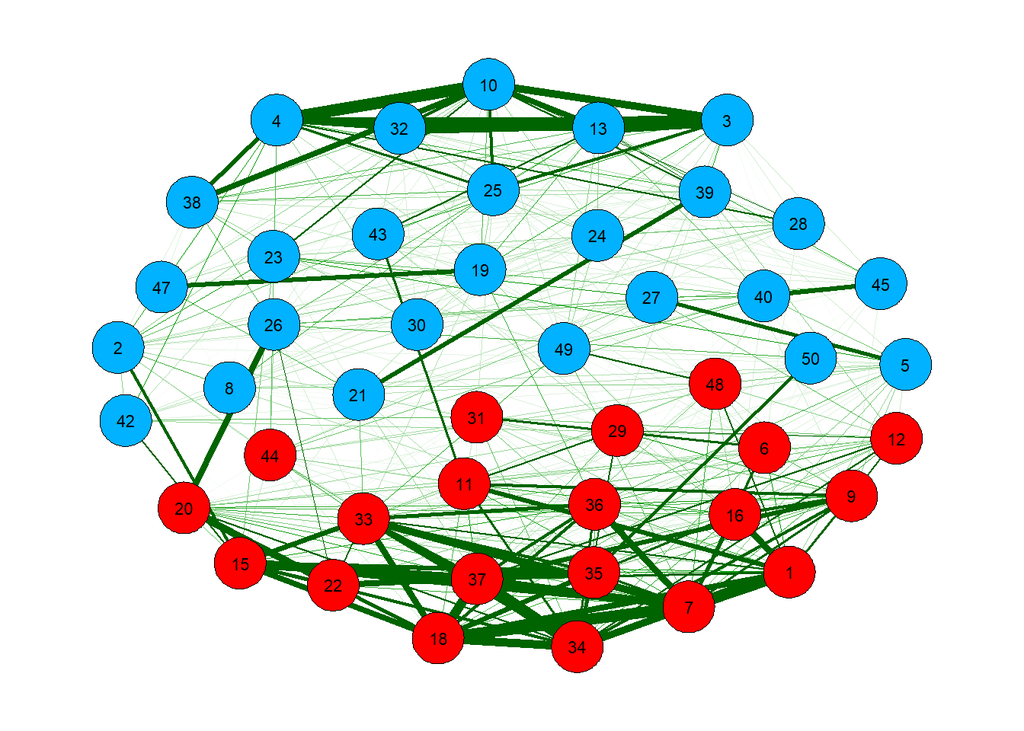

(note: this network omits correlations less than 0)

### Q3.2 k-Means Cluster Analysis of Themes

A k-means cluster analysis of the ads based on theme scores suggest ads can reasonably be broken into ~5 clusters. Based on average theme scores, these seem to correspond to:  
~M4W Hookups  
~Kink  
~Longer-Term Relationships  
~Anonymous Sex  
~Gay Male Sex

Average standardized theme scores help interpret what these clusters correspond to:

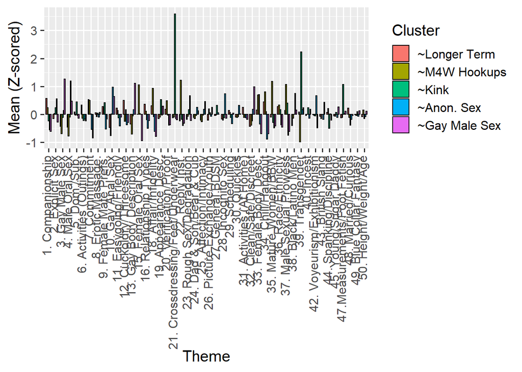

Here again, it seems that ads seeking long-term, committed, romantic relationships separate out from ads seeing short-term, primarily sexual relationships. It is noteworthy, though, that this does not appear driven entirely by sexual orientation given the emergence of separate M4W Hookups, Anonymous Sex, and Gay Male Sex clusters.

# Q4: Are there gender/sexual orientation differences in theme use?

Note: all graphs in this section are excluding all women who report being under 25 years of age. There’s a suspiciously large number of ads (*n* = 6078) from women who specifically mention being 25 or younger and these ads differ slightly from ads that don’t mention age or don’t mention being under 25. For that reason, these ads are excluded here–however, doing so does not substantially change these results.

### Q4.1 Gender Differences in Theme Scores

Plotting average theme score as a function of gender and sexual orientation largely just reveals that gay men separate from the other gender/sexual orientation groups in having higher scores on themes pertaining to gay male sex and anonymous sex.

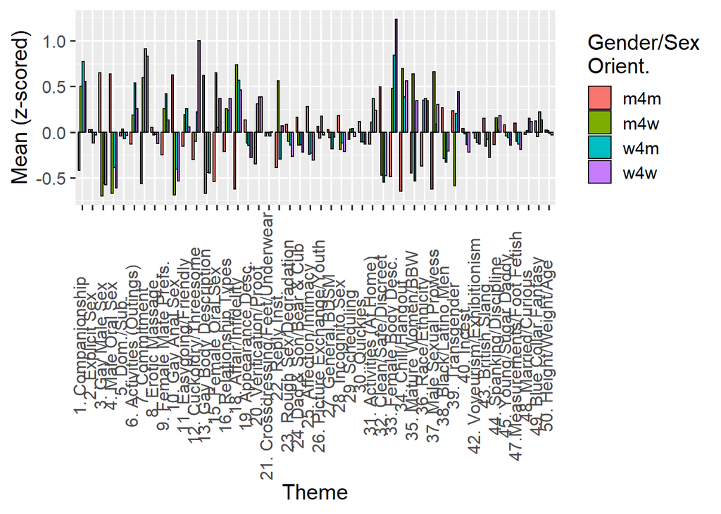

### Q4.2 Gender Differences in Clusters

Gender and sexual orientation differences in theme use are clearer when looking at the k-means clusters. Here it is clear that the majority of ads in the ~Longer term cluster are coming from w4m or w4w, followed by m4w. Relatively few from from m4m. M4W Hookups is dominated by m4w and w4w, not w4m or m4m. ~Anonymous Sex and Gay Male Sex are dominated by m4m, though more w4m appear in the anonymous sex than m4w (though both are relatively rare).

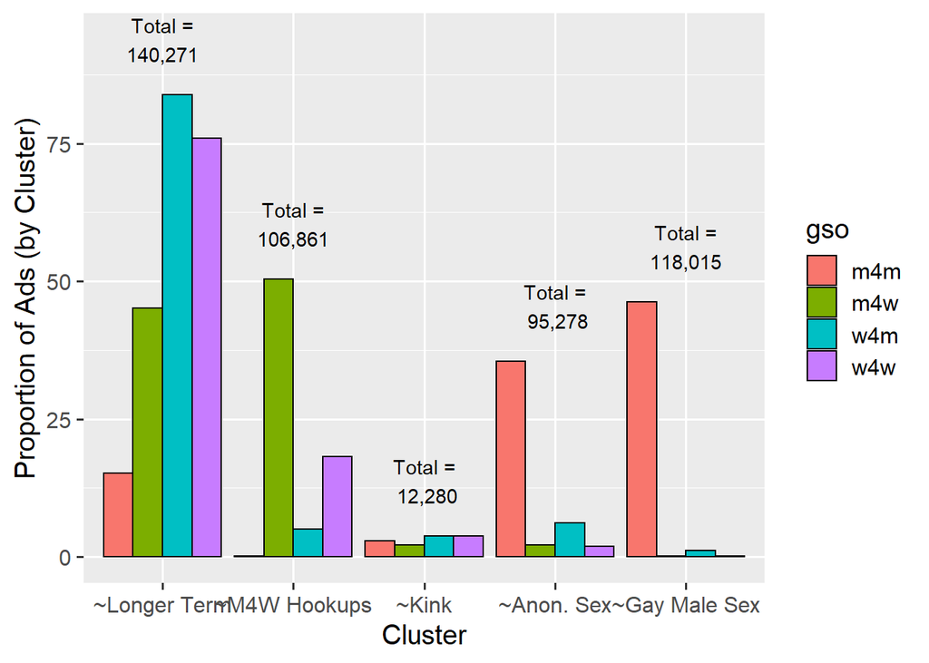

Plotting this within gender/sexual orientation category can also clarify the primary emphases of each group:

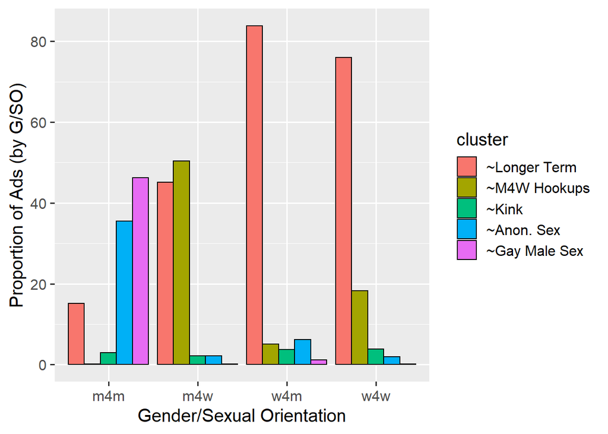

Here we see most of the ads for m4m are focusing on short-term relationships as compared to long-term relationships. M4w focus roughly equally on long-term relationships and hookups. W4m and w4w focus overwhelmingly on long-term relationships, though w4w do have some focus on hookups.

### Q5: Time, Location, and Relationship Status Relationships

I don’t think these are quite as important, but we’ve got the data so may as well take a look.

### Q5.1 Time Relationships

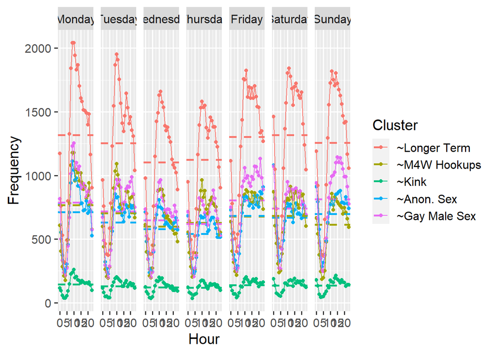

### Q5.2 Location Relationships

Not sure there’s much to say here, these are just fun

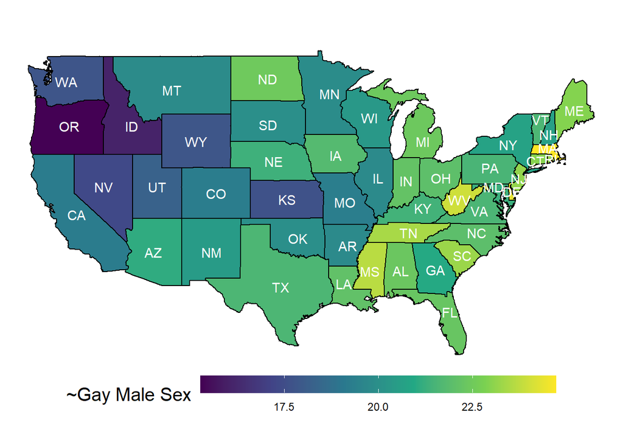

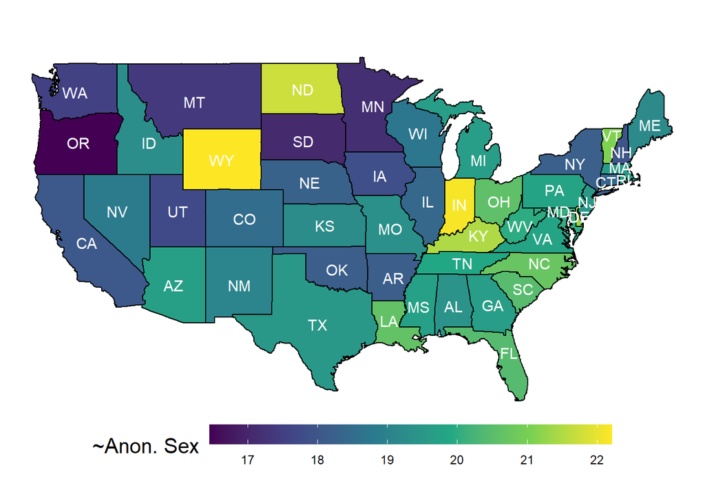

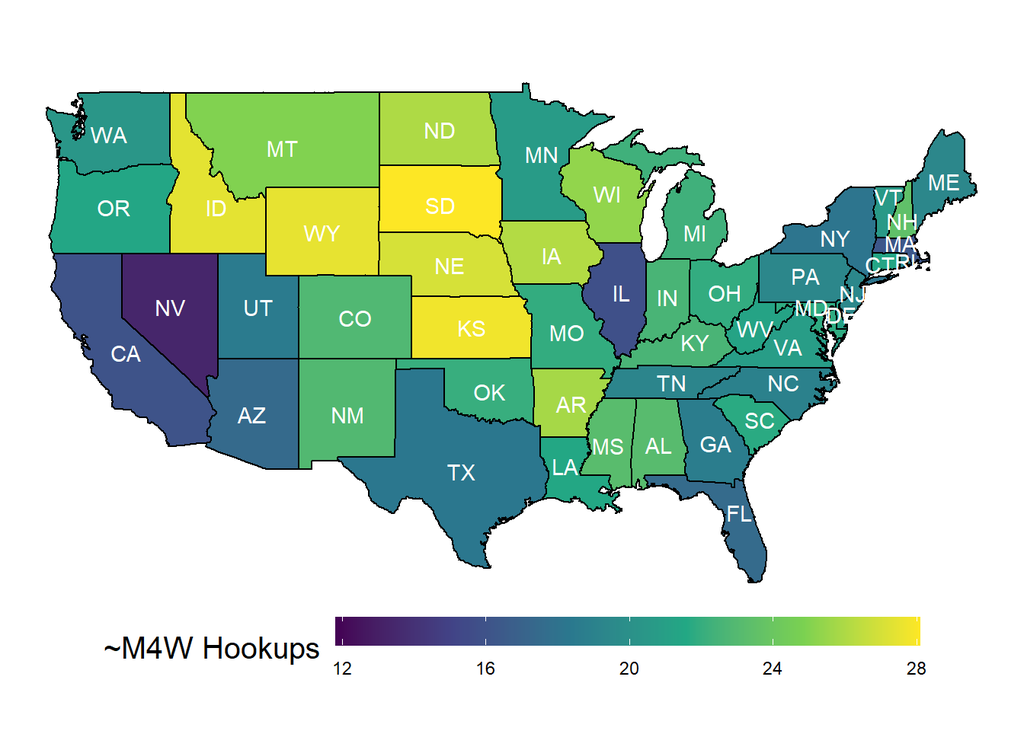

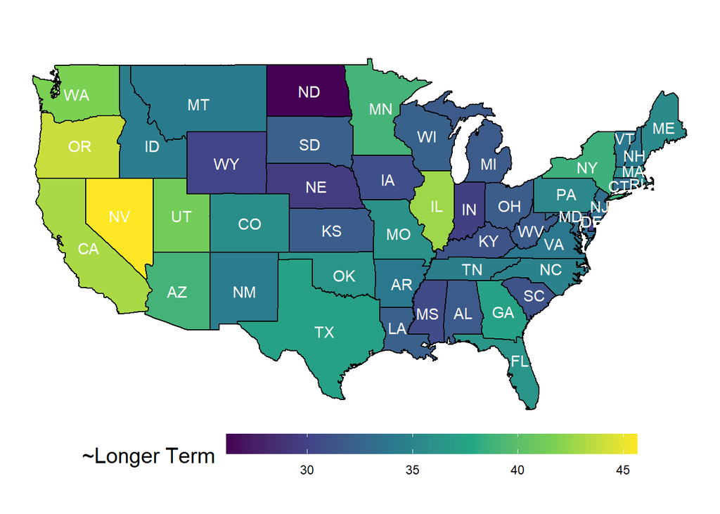

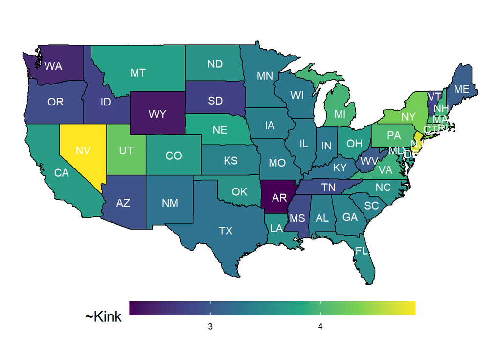

### Q5.3 Married People

Married people are less likely to talk about long-term related themes. They’re more likely to talk about threesomes, affairs, voyeurism, or curiosity about same-sex relationships.

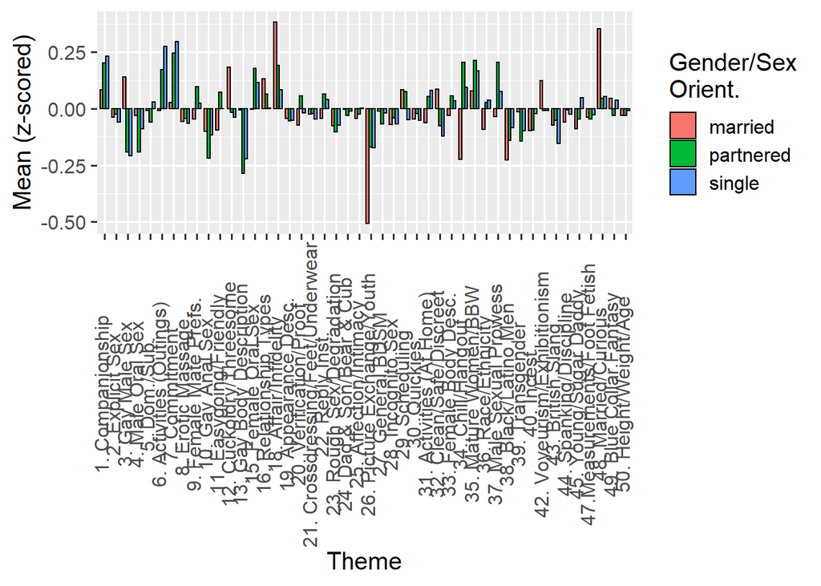